# Data visualization

## 1. matplotlib

- https://matplotlib.org
- https://matplotlib.org/gallery.html
- 파이썬에서 자료를 차트(chart)나 플롯(plot)으로 시각화하는 패키지이다.
  - line plot
  - bar chart
  - pie chart
  - histogram
  - box plot -> '상자 수염 그림'? 이라는게 있음
  - scatter plot ->산점도

  데이터의 종류와 유형에 따라서 적절한 시각화 도구를 사용해야 함!  
  데이터-> 범주형 데이터와 연속형 데이터  
  Grouping시킬 수 있는게 범주형 데이터 (학년별 데이터, 나이별 데이터 등)  
  수치형 데이터가 연속형 데이터
- line 그래프 : 시간에 따른 변화 추이 같은거 나타낼 때 (time series(시계열) data, 주가 그래프 등)
- bar 그래프 : 크기 비교 등을 나타낼 때 사용--이 때 x축에는 범주형 데이터가 와야 함
- 히스토그램 : 연속형 데이터를 x축에 쓰고 싶을 때-- 이 때 연속형 데이터를 하나하나 다 나타낼 수 없기 때문에 연속형 데이터를 구간으로 쪼개서 사용! 그래서 막대들이 다 붙어 있음
- pie 그래프 : bar 그래프랑 비슷한데 막대 길이 대신 부채꼴 넓이로 표현
- scatter plot : 연속형 데이터에서 두 변수 간의 상관관계를 알아보고자 할 때

### 1) 그림의 구조

- matplotlib가 그리는 그림은 Figure 객체, Axes 객체, Axis 객체 등으로 구성된다.
- Figure 객체는 한 개 이상의 Axes 객체를 포함하고 Axes 객체는 다시 두 개 이상의 Axis 객체를 포함한다.
- Figure는 그림이 그려지는 캔버스나 종이를 뜻하고 Axes는 하나의 플롯, 그리고 Axis는 가로축이나 세로축 등의 축을 뜻한다.

### 2) 선 그래프(line plot)

- y축에 해당하는 데이터는 반드시 입력해야 한다.
- x축에 해당하는 데이터를 입력하지 않으면 0부터 시작되는 정수로 y축 데이터의 개수에 맞춰진다.
- 그래프를 보여주려면 show() 함수를 실행한다.
  - 색 r g b k y 등
  - 마커(데이터 위치를 나타내는 기호) . , ^ s o + * 등
  - 선 - -- -. 등

```python
import matplotlib.pyplot as plt   #matplotlib 중에서 pyplot만 import
```

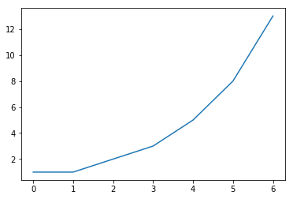

```python
#y축만 있음
plt.plot([1, 1, 2, 3, 5, 8, 13]) #이게 y축 값이 되고 x축 값은 0부터 자동으로
plt.show()
```

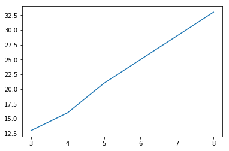

```python
# X,Y축 있음
plt.plot([3, 4, 5, 6, 7, 8], [13, 16, 21, 25, 29, 33])
plt.show()
```

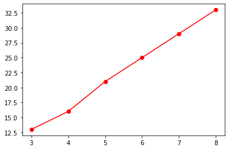

```python
plt.plot([3, 4, 5, 6, 7, 8], [13, 16, 21, 25, 29, 33], 'ro-')  # red, o , -
plt.show()
```

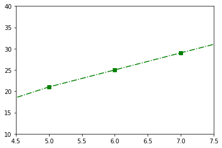

```python
plt.plot([3, 4, 5, 6, 7, 8], [13, 16, 21, 25, 29, 33], 'gs-.')
plt.axis([4.5, 7.5, 10, 40])  # [xmin, xmax, ymin, ymax] x,y축의 범위 설정!!!!!!!!!!!!!!!!!!!!!!!!!!!!!!!!!!!!!!!!!!!!!!
plt.show()
```

축 범위 설정!!!!!!!!!!!!!!!!!!!!!!!!!!!!!!!!!!!!!!!!!!!!!!!!!!!!!!!!!!!!!!!!!!!!!!!!!!!

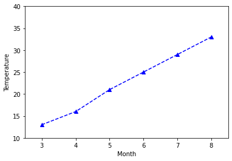

```python
plt.plot([3, 4, 5, 6, 7, 8], [13, 16, 21, 25, 29, 33], 'b^--')
plt.axis([2.5, 8.5, 10, 40])
# X축, Y축 제목 label 붙이기
plt.xlabel('Month')
plt.ylabel('Temperature')
plt.show()
```

#### 수식 활용

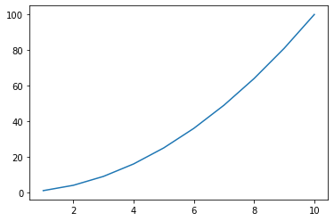

```python
import matplotlib.pyplot as plt
a = range(1, 11)
b = [i*i for i in a]
plt.plot(a, b)
plt.show()
```

- 1행 패키지 matplotlib의 모듈 pyplot을 불러와 별명 plt를 붙인다.
- 2행 range() 함수를 사용해 1~10까지 정수 리스트를 만들고 변수 a에 저장한다.
- 3행 a에 저장된 1~10까지 리스트를 순회하며 각 항목을 i에 대입하고 i*i를 구하여 이 값들에 대한 리스트를 만들어 변수 b에 저장한다.
- 4행 plt는 matplotlib.pyplot을 의미하므로 모듈 pyplot에 정의된 plot()을 실행한다. 좌표 (a, b)의 각 값을 연결하는 라인 그래프를 그린다.
- ※ 주의 리스트 a와 리스트 b의 길이(항목의 개수)는 반드시 같아야 한다.
- 5행 그래프를 출력한다. show() 함수를 사용하지 않으면 그래프를 표시할 수 없다.

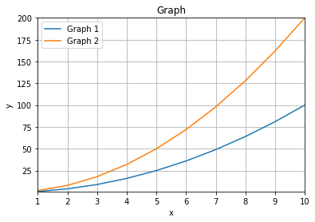

```python
import matplotlib.pyplot as plt
a = range(1, 11)
b = [i*i for i in a]
c = [2*i*i for i in a]
plt.plot(a, b, label="Graph 1")
plt.plot(a, c, label="Graph 2")
plt.title("Graph")
plt.xlabel("x")
plt.ylabel("y")
plt.legend() #범례 설정----label 설정해둔 걸로 표시됨
plt.grid()
plt.axis([1, 10, 1, 200])
plt.savefig('graph.png') #이미지 파일로 저장
plt.show()
```

#### numpy 라이브러리 활용

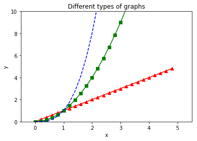

```python
# y=x, y=x**2, y=x**3
import numpy as np

x = np.arange(0, 5, 0.2)
#print(x)
y1 = x
y2 = x**2
y3 = x**3

plt.plot(x, y1, 'r^-')
plt.plot(x, y2, 'gs-')
plt.plot(x, y3, 'b--')
plt.axis([-0.5, 5.5, 0, 10])
plt.xlabel('x')
plt.ylabel('y')
plt.title('Different types of graphs')
plt.show()
```

#### pandas 라이브러리 활용

```python
import pandas as pd
data = {'name':['choco_ball', 'gum', 'potato_chip', 'bbabbaro'],
       'price':[1600, 700, 2500, 2000],
       'made':['a', 'a', 'b', 'c']}

df = pd.DataFrame(data) #딕셔너리 만들고 DataFrame이라는 함수 쓰면 됨

df['amount'] = 300

df
```

|  | name | price | made | amount |
| --- | --- | --- | --- | --- |
| 0 | choco_ball | 1600 | a | 300 |
| 1 | gum | 700 | a | 300 |
| 2 | potato_chip | 2500 | b | 300 |
| 3 | bbabbaro | 2000 | c | 300 |

```python
df.price
```

```
0    1600
1     700
2    2500
3    2000
Name: price, dtype: int64
```

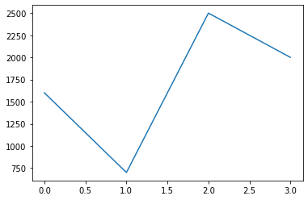

```python
plt.plot(df.price) #시리즈 하나 선택해서 그래프 그림
plt.show()
```

```python
df.groupby('made').mean() #범주형 데이터 'made' 기준으로 묶고 평균 냄
```

| made | price | amount |
| --- | --- | --- |
| a | 1150 | 300 |
| b | 2500 | 300 |
| c | 2000 | 300 |

```python
df_made = df.groupby('made').mean()
df_made.price
```

```
made
a    1150
b    2500
c    2000
Name: price, dtype: int64
```

```python
df_made.index
```

```
Index(['a', 'b', 'c'], dtype='object', name='made')
```

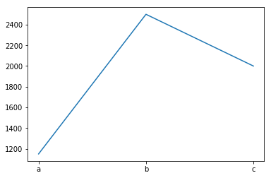

```python
plt.plot(df_made.index, df_made.price)
plt.show()
```

### 2) 막대 그래프(bar chart)

- 선 그래프와 달리 x축에 해당하는 데이터를 입력해야 한다.

#### x축에 범주형 데이터 온다 !! !!

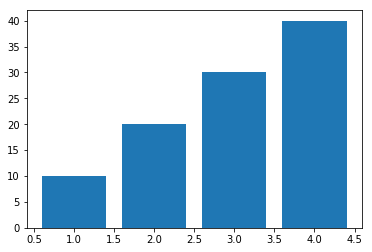

```python
import matplotlib.pyplot as plt

plt.bar([1,2,3,4],[10,20,30,40])
plt.show()
```

#### 막대 폭 설정 : width 속성

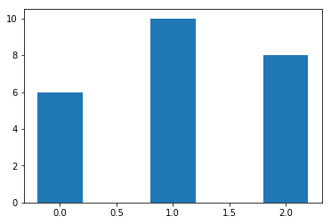

```python
x = range(3)
burger = [6, 10, 8]

plt.bar(x, burger, width = 0.4)
plt.show()
```

#### 틱 설정 : 축 상의 위치 표시 지점, xticks(), yticks()

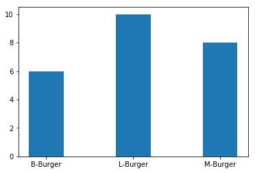

```python
x = range(3)
brand = ['B-Burger','L-Burger','M-Burger']
burger = [6, 10, 8]

plt.bar(x, burger, width = 0.4) #여기서 x는 리스트 이름임(위에 있는 저거)
plt.xticks(x, brand)
#plt.yticks([6, 10, 8])
plt.show()
```

#### 그리드 설정 : grid()

# 격자

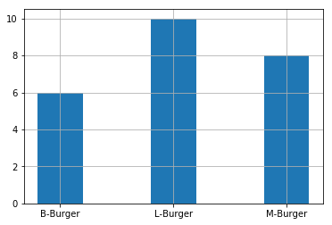

```python
x = range(3)
brand = ['B-Burger','L-Burger','M-Burger']
burger = [6, 10, 8]

plt.bar(x, burger, width = 0.4)
plt.xticks(x, brand)
#plt.yticks([6, 8, 10])
plt.grid(True)
plt.show()
```

#### 축 범위 지정 : xlim, ylim

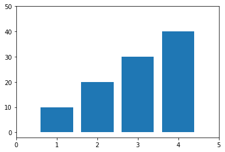

```python
plt.bar([1,2,3,4],[10,20,30,40])
plt.xlim(0, 5)
plt.ylim(-2, 50)
plt.show()
```

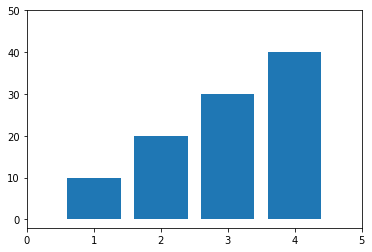

```python
plt.bar([1,2,3,4],[10,20,30,40])
plt.axis([0, 5, -2, 50])  #결과 같음
plt.show()
```

#### 범례 설정 : legend()

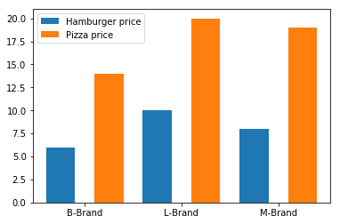

```python
x1 = range(1, 6, 2) #1, 3, 5
x2 = range(2, 7, 2) #2, 4, 6

burger = [6, 10, 8]
pizza = [14, 20, 19]

brand = ['B-Brand','L-Brand','M-Brand']

plt.bar(x1, burger, width = 0.6, label='Hamburger price')  #범례를 위해 label 필요!!!!!!!
plt.bar(x2, pizza, width = 0.6, label='Pizza price')
plt.xticks([1.5, 3.5, 5.5], brand)

plt.legend()
plt.show()
```

#### 수평 막대 그래프 : barh()

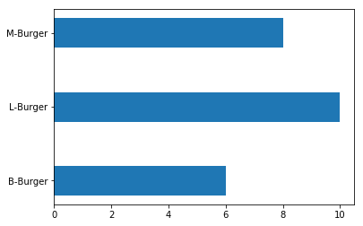

```python
x = range(3)
brand = ['B-Burger','L-Burger','M-Burger']
burger = [6, 10, 8]

plt.barh(x, burger, height = 0.4)
plt.yticks(x, brand)
plt.show()
```

#### 실습 : df 데이터셋에서 제조회사별 가격 평균을 막대 그래프 이용해 시각화

```python
df
```

|  | name | price | made | amount |
| --- | --- | --- | --- | --- |
| 0 | choco_ball | 1600 | a | 300 |
| 1 | gum | 700 | a | 300 |
| 2 | potato_chip | 2500 | b | 300 |
| 3 | bbabbaro | 2000 | c | 300 |

```python
df_made = df.groupby('made').mean()
df_made
```

| made | price | amount |
| --- | --- | --- |
| a | 1150 | 300 |
| b | 2500 | 300 |
| c | 2000 | 300 |

```python
df_made.price
```

```
made
a    1150
b    2500
c    2000
Name: price, dtype: int64
```

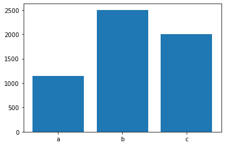

```python
#실습 : 제조회사별 가격 평균을 막대 그래프 이용해 시각화
plt.bar(df_made.index,df_made.price)
plt.show()
```

```python
import pandas as pd
tit = pd.read_csv('titanic_train.csv')

tit.head()

#연속형 데이터와 범주형 데이터 잘 구분해보기!!!!!!!!!!!!!!!!!!!!!!!
```

|  | PassengerId | Survived | Pclass | Name | Sex | Age | SibSp | Parch | Ticket | Fare | Cabin | Embarked |
| --- | --- | --- | --- | --- | --- | --- | --- | --- | --- | --- | --- | --- |
| 0 | 1 | 0 | 3 | Braund, Mr. Owen Harris | male | 22.0 | 1 | 0 | A/5 21171 | 7.2500 | NaN | S |
| 1 | 2 | 1 | 1 | Cumings, Mrs. John Bradley (Florence Briggs Th... | female | 38.0 | 1 | 0 | PC 17599 | 71.2833 | C85 | C |
| 2 | 3 | 1 | 3 | Heikkinen, Miss. Laina | female | 26.0 | 0 | 0 | STON/O2. 3101282 | 7.9250 | NaN | S |
| 3 | 4 | 1 | 1 | Futrelle, Mrs. Jacques Heath (Lily May Peel) | female | 35.0 | 1 | 0 | 113803 | 53.1000 | C123 | S |
| 4 | 5 | 0 | 3 | Allen, Mr. William Henry | male | 35.0 | 0 | 0 | 373450 | 8.0500 | NaN | S |

```python
tit.groupby('Pclass').mean() #연속형 변수에 대해서만 mean을 구해주는데, survived같은건 컴퓨터는 범주형인지 몰라서 일단 평균 구해줌
```

| Pclass | PassengerId | Survived | Age | SibSp | Parch | Fare |
| --- | --- | --- | --- | --- | --- | --- |
| 1 | 461.597222 | 0.629630 | 38.233441 | 0.416667 | 0.356481 | 84.154687 |
| 2 | 445.956522 | 0.472826 | 29.877630 | 0.402174 | 0.380435 | 20.662183 |
| 3 | 439.154786 | 0.242363 | 25.140620 | 0.615071 | 0.393075 | 13.675550 |

```python
tit_pclass = tit.groupby('Pclass').mean()
tit_pclass
```

| Pclass | PassengerId | Survived | Age | SibSp | Parch | Fare |
| --- | --- | --- | --- | --- | --- | --- |
| 1 | 461.597222 | 0.629630 | 38.233441 | 0.416667 | 0.356481 | 84.154687 |
| 2 | 445.956522 | 0.472826 | 29.877630 | 0.402174 | 0.380435 | 20.662183 |
| 3 | 439.154786 | 0.242363 | 25.140620 | 0.615071 | 0.393075 | 13.675550 |

```python
tit_pclass.index
```

```
Int64Index([1, 2, 3], dtype='int64', name='Pclass')
```

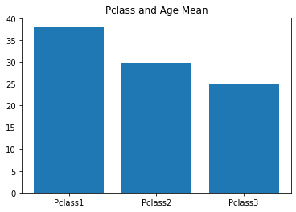

```python
tit_pclass = tit.groupby('Pclass').mean()
plt.bar(tit_pclass.index, tit_pclass.Age)

plt.title('Pclass and Age Mean')
plt.xticks(tit_pclass.index, ['Pclass1','Pclass2','Pclass3'])

plt.show()
```

### 3) 히스토그램 (histogram)

- 도수분포 : 표본의 다양한 산출 분포를 나타낸 것. 각 항목은 특정 그룹이나 주기 안에 값이 발생한 빈도나 횟수를 포함한다.
- 히스토그램 : 도수분포표를 그래프로 나타낸 것
- hist() : 히스토그램 그리기, 데이터 집계 결과를 반환한다.
- bins 인수로 데이터를 집계할 구간 정보를 받는다.

#### x축에 연속형 변수!!! , 연속형 변수를 구간으로 나눠서 나타냄->막대들이 붙어 있음

#### 범주형 변수 쓰는 막대그래프랑은 다름

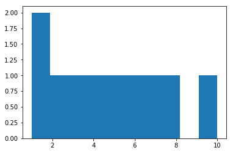

```python
plt.hist([1,1,2,3,4,5,6,7,8,10])
plt.show()
```

#### bins는 막대 개수(즉 구간을 몇 개로 나누냐)

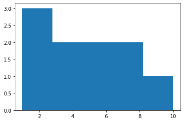

```python
plt.hist([1,1,2,3,4,5,6,7,8,10], bins = 5)
plt.show()
```

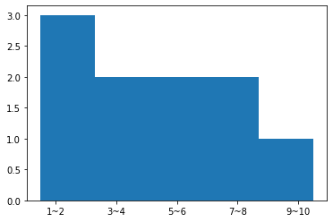

```python
plt.hist([1,1,2,3,4,5,6,7,8,10], bins = 5)
plt.xticks([1.5, 3.5, 5.5, 7.5, 9.5],['1~2','3~4','5~6', '7~8', '9~10'])
plt.show()
```

```python
import pandas as pd
st = pd.read_csv('state_sm.csv')
st.head()
```

|  | State | Population | Income | Illiteracy | Life.Exp | Murder |
| --- | --- | --- | --- | --- | --- | --- |
| 0 | Alabama | 3615 | 3624 | 2.1 | 69.05 | 15.1 |
| 1 | Alaska | 365 | 6315 | 1.5 | 69.31 | 11.3 |
| 2 | Arizona | 2212 | 4530 | 1.8 | 70.55 | 7.8 |
| 3 | Arkansas | 2110 | 3378 | 1.9 | 70.66 | 10.1 |
| 4 | California | 21198 | 5114 | 1.1 | 71.71 | 10.3 |

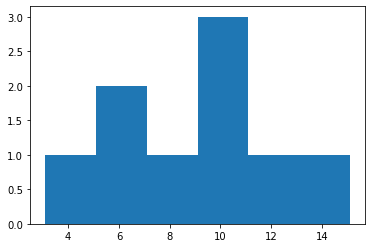

```python
plt.hist(st.Murder, bins = 6)
plt.show()
```

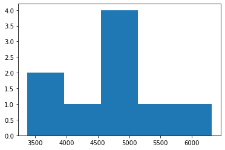

```python
plt.hist(st.Income, bins = 5)
plt.show()
```

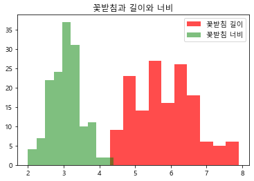

```python
import pandas as pd
import matplotlib.pyplot as plt

ir = pd.read_csv('iris(150).csv', encoding='cp949')
plt.rc('font', family='Malgun Gothic') #한글 지원은 plt.rc

plt.hist(ir['꽃받침 길이'], color = 'red', alpha = 0.7, label = '꽃받침 길이')
plt.hist(ir['꽃받침 너비'], color = 'green', alpha = 0.5, label = '꽃받침 너비')

#alpha는 투명도!!!!!!!!!!!(opacity)
#그래프가 겹쳐 있을 때 사용

plt.title('꽃받침과 길이와 너비')
plt.legend()
plt.show()
```

#### 실습 : 아이리스 꽃받침과 꽃잎의 길이를 비교하기 위한 히스토 그램을 작성

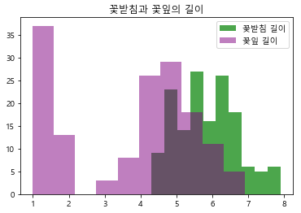

```python
plt.hist(ir['꽃받침 길이'], color = 'green', alpha = 0.7, label = '꽃받침 길이')
plt.hist(ir['꽃잎 길이'], color = 'purple', alpha = 0.5, label = '꽃잎 길이')

plt.title('꽃받침과 꽃잎의 길이')
plt.legend()
plt.show()
```